# Frequency of words given their function in a sentence

Mazunki Hoksaas

2023-09-30

## Introduction

This analysis uses the “perry_winter_2017_iconicity.csv” dataset to explore the relationship between word frequency and part of speech using R and ggplot2.

Our intention here is to prove, given the provided dataset, that verbs in sentences are disproportionally iconic compared to other parts of speech.

## First look

```r
head(read.csv("perry_winter_2017_iconicity.csv"))
```

```
##       Word         POS  SER CorteseImag Conc Syst    Freq  Iconicity
## 1        a Grammatical   NA          NA 1.46   NA 1041179  0.4615385
## 2    abide        Verb   NA          NA 1.68   NA     138  0.2500000
## 3     able   Adjective 1.73          NA 2.38   NA    8155  0.4666667
## 4    about Grammatical 1.20          NA 1.77   NA  185206 -0.1000000
## 5    above Grammatical 2.91          NA 3.33   NA    2493  1.0625000
## 6 abrasive   Adjective   NA          NA 3.03   NA      23  1.3125000
```

By checking the first rows of the data we can see we have columns for the words, their part of speech, their frequency and their iconicity. This is enough for what we need.

Additionally, we can see some other columns for the sensory experience (SER), their imageability (how easy it is to form an image of the word in our head), their systematicity (how strong their sound-meaning link is). I’m guessing the Conc column stands for Concreteness (as opposed to abstractness).

```r
data <- read.csv("perry_winter_2017_iconicity.csv", row.names=1) %>%
        select(POS, Freq, Iconicity)

verbs <- filter(data, POS == "Verb")
other <- filter(data, POS != "Verb")

data <- bind_rows(
    verbs %>% mutate(Group = "Verb"),
    other %>% mutate(Group = "Non-verb")
  ) %>% arrange(Group)  # there's not many verbs compared to other POS
```

We start by taking an overview at what the most frequent words are, followed by which words are the most iconic

```r
# tbh i feel this code is kind of ugly, maybe there's a cleaner way to order() dataframes...

print(head(verbs[order(-verbs$Freq, -verbs$Iconicity), ], n=10))
```

```
##       POS   Freq  Iconicity
## is   Verb 459663 -0.1428571
## have Verb 314232 -0.2666667
## do   Verb 312915  0.8461538
## be   Verb 293085  0.3846154
## know Verb 291780  0.7692308
## was  Verb 288391 -0.8333333
## are  Verb 265672 -0.9000000
## get  Verb 233772 -0.5833333
## go   Verb 193445  1.4545455
## come Verb 160190  0.2142857
```

```r
print(head(other[order(-other$Freq, -other$Iconicity), ], n=20))
```

```
##               POS    Freq  Iconicity
## you   Grammatical 2134713 -0.4000000
## I     Grammatical 2038529  3.1818182
## the   Grammatical 1501908  0.4285714
## to    Grammatical 1156570 -0.4166667
## a     Grammatical 1041179  0.4615385
## it    Grammatical  963712  1.0000000
## that  Grammatical  719677 -0.0625000
## and   Grammatical  682780  0.5625000
## of    Grammatical  590439  0.2307692
## what  Grammatical  501965  0.1428571
## in    Grammatical  498444  1.4615385
## me    Grammatical  471339  0.6000000
## we    Grammatical  459607  1.4285714
## this  Grammatical  406915  0.1333333
## he    Grammatical  389497  1.0588235
## on    Grammatical  354742  0.9166667
## for   Grammatical  351650 -1.4000000
## my    Grammatical  344899  1.5000000
## your  Grammatical  328715  0.0000000
## no   Interjection  304549  2.8125000
```

```r
# and finally we look at the most iconic words
print(head(data[order(-data$Iconicity, -data$Freq), ], n=20))
```

```
##                  POS Freq Iconicity    Group
## humming         Verb  251  4.466667     Verb
## click           Verb  327  4.461538     Verb
## hissing         Verb   73  4.461538     Verb
## gurgle          Verb   12  4.416667     Verb
## mushy      Adjective   77  4.384615 Non-verb
## beep            Noun  332  4.357143 Non-verb
## screech         Noun  318  4.333333 Non-verb
## buzzing         Verb  221  4.333333     Verb
## zigzag          Noun   23  4.300000 Non-verb
## squeak          Verb  121  4.230769     Verb
## icky       Adjective   61  4.200000 Non-verb
## goopy      Adjective    5  4.200000 Non-verb
## hiss            Verb   47  4.153846     Verb
## clank           Noun   16  4.153846 Non-verb
## chirp           Verb   30  4.142857     Verb
## stomp           Verb  136  4.100000     Verb
## buzzer          Noun  201  4.090909 Non-verb
## pop     Interjection 3441  4.076923 Non-verb
## quack   Interjection  236  4.076923 Non-verb
## cooing          Verb   24  4.076923     Verb
```

An interesting observation is how predominant grammatical words are in the data set, but otherwise we don’t see too much interesting stuff in these tables just yet.

## Summary and conclusion

```r
print(summary(verbs))
```

```
##      POS                 Freq          Iconicity
##  Length:557         Min.   :     1   Min.   :-2.1000
##  Class :character   1st Qu.:    62   1st Qu.: 0.4286
##  Mode  :character   Median :   373   Median : 1.2308
##                     Mean   : 10534   Mean   : 1.3804
##                     3rd Qu.:  2758   3rd Qu.: 2.2857
##                     Max.   :459663   Max.   : 4.4667
```

```r
print(summary(other))
```

```
##      POS                 Freq             Iconicity
##  Length:2390        Min.   :      1.0   Min.   :-2.80000
##  Class :character   1st Qu.:     75.2   1st Qu.: 0.09091
##  Mode  :character   Median :    354.5   Median : 0.70000
##                     Mean   :  11216.6   Mean   : 0.80580
##                     3rd Qu.:   1511.8   3rd Qu.: 1.42559
##                     Max.   :2134713.0   Max.   : 4.38462
```

The summary tells us that the frequency of words is very disparate, where some words are used extremely often, while other words are barely used at all. This is the case for both groups.

To continue, we display the distribution of the iconicity level of words according to their frequency.

```r
ggplot2::ggplot
```

[output not shown]

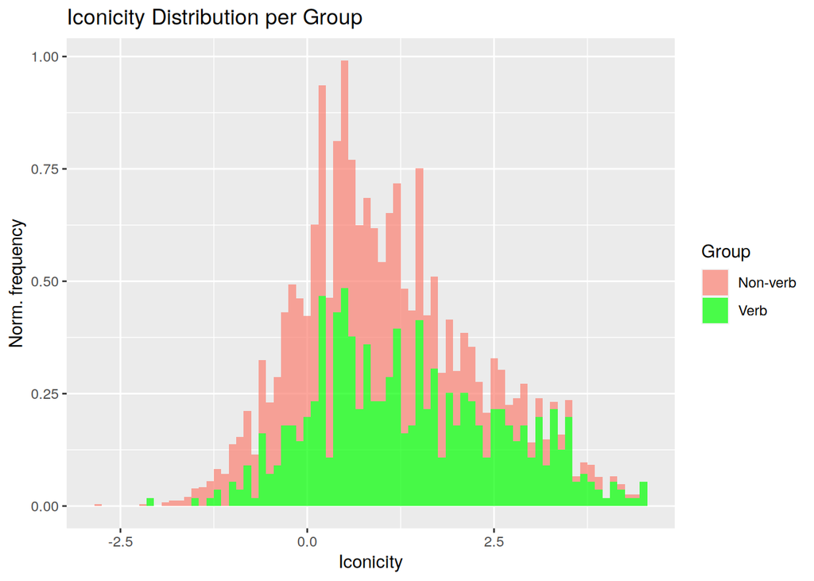

```r
ggplot(data=data, aes(
    y=after_stat(density),  # density to normalize the frequency values
    x=Iconicity,
    fill=Group)
  ) +
  geom_histogram(binwidth=0.1, alpha=0.7) +
  scale_fill_manual(values=c("Verb"="green", "Non-verb"="salmon")) +
  ggtitle("Iconicity Distribution per Group") +
  xlab("Iconicity") +
  ylab("Norm. frequency")
```

```r
ggsave("iconicity-per-pos.png")
```

The most iconic words fall well under the 0.25 distribution on their frequency for both groups. While it seems verbs do have a more linear distribution than their contrasted group, I believe this is best explained by the outliers of the grammatical words.

Overall, it seems that verbs are slightly more iconic than other groups, but the variance may be better explained through other factors.